# Lab 4: Spatial Predictive Analysis

Analyzing 311 Violations

Author

Gab Chen

Published

March 28, 2026

## Assignment Overview

In this lab, you will apply the spatial predictive modeling techniques demonstrated in the class exercise using a different 311 service request type of your choice as the predictor variable. You will build a complete spatial predictive model, document your process, and interpret your results.

### Learning Objectives

By completing this assignment, you will demonstrate your ability to:

- Adapt example code to analyze a new dataset
- Build spatial features for predictive modeling
- Apply count regression techniques to spatial data
- Implement spatial cross-validation
- Interpret and communicate model results
- Critically evaluate model performance

## Step 1: Choose Your 311 Violation Type

### Getting the Data

Visit the Chicago 311 Service Requests dataset:

https://data.cityofchicago.org/stories/s/311-Dataset-Changes-12-11-2018/d7nq-5g7t

Browse the available service request types (e.g., Graffiti Removal, Pothole Repair, Street Light Out, Sanitation Code Violations, etc.) and **choose one violation type** that interests you.

### Requirements for Your Choice

## Choose a **different** violation type than the abandoned cars we did in class.

## Step 2: Complete the Analysis

Using the class exercise as your template, adapt the code to analyze your chosen 311 violation type.

### What to Include

Work through all major sections of the analysis:

#### Part 1: Data Loading & Exploration

- Load your 311 data and Chicago spatial boundaries
- Create visualizations showing the spatial distribution of your violation type
- Describe patterns you observe

```r
# Load required packages
library(tidyverse)      # Data manipulation
library(sf)             # Spatial operations
library(here)           # Relative file paths
library(viridis)        # Color scales
library(terra)          # Raster operations (replaces 'raster')
library(spdep)          # Spatial dependence
library(FNN)            # Fast nearest neighbors
library(MASS)           # Negative binomial regression
library(patchwork)      # Plot composition (replaces grid/gridExtra)
library(knitr)          # Tables
library(kableExtra)     # Table formatting
library(classInt)       # Classification intervals
library(ggplot2)


# Spatstat for analyzing point patterns - split into sub-packages
library(spatstat.geom)    # Spatial geometries
library(spatstat.explore) # Spatial exploration/KDE

# Set options
options(scipen = 999)  # No scientific notation
set.seed(5080)         # Reproducibility, could be any number

cat("✓ All packages loaded successfully!\n")
```

```
✓ All packages loaded successfully!
```

```r
cat("✓ Working directory:", getwd(), "\n")
```

```
✓ Working directory: C:/Users/Gab/OneDrive/Documents/SPRING 2026/CPLN5920_PPA/PPA_Portfolio/lab/lab4
```

```r
# Load garbage cart requests (Illinois State Plane East, NAD83, US Feet)
cart <- st_read("311_Service_Requests_-_Garbage_Carts_-_Historical_20260328.csv") %>%
    filter(!is.na(Longitude) & !is.na(Latitude), # Remove missing coords
          Longitude != "", Latitude != "",
          Longitude != 0, Latitude != 0   # also catches (0,0) dummy coords
           ) %>%
  st_as_sf(coords = c("Longitude", "Latitude"), crs = 4326) %>%
  st_transform('ESRI:102271')  # Match Chicago boundary CRS
# Load from provided data file (downloaded from Chicago open data portal)
burglaries <- st_read("burglaries.shp") %>%
  st_transform('ESRI:102271')  # Match Chicago boundary CRS
glimpse(burglaries)
```

```
Rows: 7,482
Columns: 23
$ ID       <int> 10801247, 10801593, 10801602, 10801904, 10801956, 10802305, 1…
$ Cs_Nmbr  <chr> "JA100159", "JA100586", "JA100376", "JA100943", "JA101022", "…
$ Date     <date> 2017-01-01, 2017-01-01, 2017-01-01, 2017-01-02, 2017-01-01, …
$ Block    <chr> "048XX N KEDZIE AVE", "054XX W CHICAGO AVE", "057XX S MOZART …
$ IUCR     <chr> "0610", "0610", "0610", "0610", "0610", "0610", "0610", "0610…
$ Prmry_T  <chr> "BURGLARY", "BURGLARY", "BURGLARY", "BURGLARY", "BURGLARY", "…
$ Dscrptn  <chr> "FORCIBLE ENTRY", "FORCIBLE ENTRY", "FORCIBLE ENTRY", "FORCIB…
$ Lctn_Ds  <chr> "RESTAURANT", "SMALL RETAIL STORE", "RESIDENCE-GARAGE", "RESI…
$ Arrest   <chr> "true", "false", "false", "true", "false", "false", "false", …
$ Domestc  <chr> "false", "false", "false", "false", "false", "false", "false"…
$ Beat     <int> 1713, 1524, 824, 722, 724, 1723, 732, 935, 1432, 334, 2533, 1…
$ Distrct  <int> 17, 15, 8, 7, 7, 17, 7, 9, 14, 3, 25, 12, 16, 25, 3, 4, 12, 1…
$ Ward     <int> 33, 37, 16, 6, 17, 39, 17, 3, 1, 7, 37, 1, 38, 31, 5, 7, 1, 4…
$ Cmmnt_A  <int> 14, 25, 63, 69, 67, 16, 68, 61, 21, 43, 25, 24, 15, 20, 43, 4…
$ FBI_Cod  <chr> "05", "05", "05", "05", "05", "05", "05", "05", "05", "05", "…
$ X_Crdnt  <int> 1154172, 1139598, 1158356, 1176576, 1168818, 1150614, 1172237…
$ Y_Crdnt  <int> 1931913, 1904799, 1866496, 1859716, 1860109, 1928503, 1856217…
$ Year     <int> 2017, 2017, 2017, 2017, 2017, 2017, 2017, 2017, 2017, 2017, 2…
$ Updtd_O  <date> 2017-02-14, 2017-02-14, 2017-02-14, 2018-02-10, 2017-02-14, …
$ Latitud  <dbl> 41.96900, 41.89488, 41.78940, 41.77041, 41.77166, 41.95971, 4…
$ Longitd  <dbl> -87.70849, -87.76275, -87.69490, -87.62830, -87.65672, -87.72…
$ Locatin  <chr> "(41.968999706, -87.708494241)", "(41.894875219, -87.76274673…
$ geometry <POINT [m]> POINT (351792.8 588847.4), POINT (347350.6 580583), POI…
```

```r
# Check the data
cat("\n✓ Loaded burglary data\n")
```

```
✓ Loaded burglary data
```

```r
cat("  - Number of burglaries:", nrow(burglaries), "\n")
```

```
  - Number of burglaries: 7482
```

```r
cat("  - CRS:", st_crs(burglaries)$input, "\n")
```

```
  - CRS: ESRI:102271
```

```r
cat("  - Date range:", format(min(burglaries$Date, na.rm = TRUE)), "to",
    format(max(burglaries$Date, na.rm = TRUE)), "\n")
```

```
  - Date range: 2017-01-01 to 2018-01-01
```

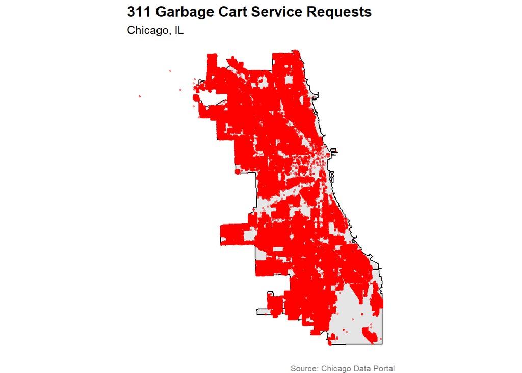

```r
# Load Chicago boundary
chicagoBoundary <-
  st_read("https://raw.githubusercontent.com/urbanSpatial/Public-Policy-Analytics-Landing/master/DATA/Chapter5/chicagoBoundary.geojson") %>%
  st_transform('ESRI:102271')
# Load police districts (used for spatial cross-validation)
policeDistricts <-
  st_read("https://data.cityofchicago.org/api/geospatial/24zt-jpfn?method=export&format=GeoJSON") %>%
  st_transform('ESRI:102271') %>%
  dplyr::select(District = dist_num)
# Plot garbage cart service requests in Chicago
ggplot() +
  geom_sf(data = chicagoBoundary, fill = "grey90", color = "black", linewidth = 0.5) +
  geom_sf(data = cart, color = "red", size = 0.5, alpha = 0.4) +
  labs(
    title = "311 Garbage Cart Service Requests",
    subtitle = "Chicago, IL",
    caption = "Source: Chicago Data Portal"
  ) +
  theme_void() +
  theme(
    plot.title = element_text(face = "bold", size = 14),
    plot.subtitle = element_text(size = 11),
    plot.caption = element_text(size = 8, color = "grey50")
  )
```

```r
cat("✓ Loaded spatial boundaries\n")
```

```
✓ Loaded spatial boundaries
```

```r
cat("✓ Loaded Garbage cart service request\n")
```

```
✓ Loaded Garbage cart service request
```

```r
cat("✓ Loaded Police districts\n")
```

```
✓ Loaded Police districts
```

```r
cat("  - Garbage cart service request:", nrow(cart), "\n")
```

```
  - Garbage cart service request: 403716
```

#### Part 2: Fishnet Grid Creation

```r
# Create 500ft x 500ft grid
fishnet <- st_make_grid(
  chicagoBoundary,
  cellsize = 500,  # 500 feet per cell
  square = TRUE
) %>%
  st_sf() %>%
  mutate(uniqueID = row_number()) %>%
  st_transform('ESRI:102271')

# Keep only cells that intersect Chicago
fishnet <- fishnet[chicagoBoundary, ]

# View basic info
cat("✓ Created fishnet grid\n")
```

```
✓ Created fishnet grid
```

```r
cat("  - Number of cells:", nrow(fishnet), "\n")
```

```
  - Number of cells: 2458
```

```r
cat("  - Cell size:", 500, "x", 500, "feet\n")
```

```
  - Cell size: 500 x 500 feet
```

```r
cat("  - Cell area:", round(st_area(fishnet[1,])), "square feet\n")
```

```
  - Cell area: 250000 square feet
```

```r
# Spatial join: which cell contains each garbage cart service request?
cart_fishnet <- st_join(cart, fishnet, join = st_within) %>%
  st_drop_geometry() %>%
  group_by(uniqueID) %>%
  summarize(countcarts = n())


glimpse(cart_fishnet)
```

```
Rows: 2,099
Columns: 2
$ uniqueID   <int> 38, 50, 90, 91, 92, 93, 102, 103, 104, 105, 139, 140, 141, …
$ countcarts <int> 84, 26, 10, 51, 78, 3, 104, 144, 136, 1, 3, 21, 15, 24, 164…
```

```r
st_crs(cart_fishnet)
```

```
Coordinate Reference System: NA
```

```r
# Join back to fishnet (cells with 0 requests will be NA)
fishnet <- fishnet %>%
  left_join(cart_fishnet, by = "uniqueID") %>%
  mutate(countcarts = replace_na(countcarts, 0))

# Summary statistics
cat("\nCart count distribution:\n")
```

```
Cart count distribution:
```

```r
summary(fishnet$countcarts)
```

```
   Min. 1st Qu.  Median    Mean 3rd Qu.    Max.
      0      24     151     164     260     802
```

```r
cat("\nCells with zero barbage cart requests:",
    sum(fishnet$countcarts == 0),
    "/", nrow(fishnet),
    "(", round(100 * sum(fishnet$countcarts == 0) / nrow(fishnet), 1), "%)\n")
```

```
Cells with zero barbage cart requests: 360 / 2458 ( 14.6 %)
```

```r
# Spatial join: which cell contains each burglary?
burglaries_fishnet <- st_join(burglaries, fishnet, join = st_within) %>%
  st_drop_geometry() %>%
  group_by(uniqueID) %>%
  summarize(countBurglaries = n())


glimpse(burglaries_fishnet)
```

```
Rows: 1,678
Columns: 2
$ uniqueID        <int> 38, 45, 50, 92, 102, 103, 105, 140, 144, 145, 146, 147…
$ countBurglaries <int> 2, 1, 2, 1, 6, 4, 1, 1, 7, 4, 1, 1, 2, 5, 3, 5, 2, 2, …
```

```r
st_crs(burglaries_fishnet)
```

```
Coordinate Reference System: NA
```

```r
# Join back to fishnet (cells with 0 burglaries will be NA)
fishnet <- fishnet %>%
  left_join(burglaries_fishnet, by = "uniqueID") %>%
  mutate(countBurglaries = replace_na(countBurglaries, 0))

# Summary statistics
cat("\nBurglary count distribution:\n")
```

```
Burglary count distribution:
```

```r
summary(fishnet$countBurglaries)
```

```
   Min. 1st Qu.  Median    Mean 3rd Qu.    Max.
  0.000   0.000   2.000   3.042   5.000  40.000
```

```r
cat("\nCells with zero burglaries:",
    sum(fishnet$countBurglaries == 0),
    "/", nrow(fishnet),
    "(", round(100 * sum(fishnet$countBurglaries == 0) / nrow(fishnet), 1), "%)\n")
```

```
Cells with zero burglaries: 781 / 2458 ( 31.8 %)
```

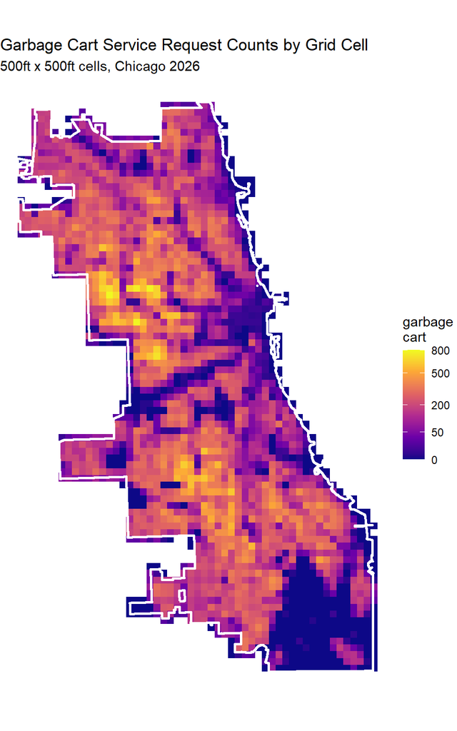

```r
# Visualize aggregated counts
ggplot() +
  geom_sf(data = fishnet, aes(fill = countcarts), color = NA) +
  geom_sf(data = chicagoBoundary, fill = NA, color = "white", linewidth = 1) +
  scale_fill_viridis_c(
    name = "garbage \ncart",
    option = "plasma",
    trans = "sqrt",  # Square root for better visualization of skewed data
    breaks = c(0, 50, 200, 500, 800)
  ) +
  labs(
    title = "Garbage Cart Service Request Counts by Grid Cell",
    subtitle = "500ft x 500ft cells, Chicago 2026"
  ) +
  theme_void()
```

#### Part 3: Spatial Features

- Calculate k-nearest neighbor features
- Perform Local Moran’s I analysis
- Identify hot spots and cold spots
- Create distance-to-hotspot measures
- Join any additional contextual data if you are looking for more to do and really get into this (e.g., demographics, land use)

```r
# Calculate mean distance to 3 nearest garbage carts
# (Do this OUTSIDE of mutate to avoid sf conflicts)

# Get coordinates
fishnet_coords <- st_coordinates(st_centroid(fishnet))
cart_coords <- st_coordinates(cart)

# Calculate k nearest neighbors and distances
nn_result <- get.knnx(cart_coords, fishnet_coords, k = 3)

# Add to fishnet
fishnet <- fishnet %>%
  mutate(
    carts.nn = rowMeans(nn_result$nn.dist)
  )

cat("✓ Calculated nearest neighbor distances\n")
```

```
✓ Calculated nearest neighbor distances
```

```r
summary(fishnet$carts.nn)
```

```
    Min.  1st Qu.   Median     Mean  3rd Qu.     Max.
   0.908   25.908   48.518  166.813  179.045 1978.298
```

```r
# Function to calculate Local Moran's I
calculate_local_morans <- function(data, variable, k = 5) {

  # Create spatial weights
  coords <- st_coordinates(st_centroid(data))
  neighbors <- knn2nb(knearneigh(coords, k = k))
  weights <- nb2listw(neighbors, style = "W", zero.policy = TRUE)

  # Calculate Local Moran's I
  local_moran <- localmoran(data[[variable]], weights)

  # Classify clusters
  mean_val <- mean(data[[variable]], na.rm = TRUE)

  data %>%
    mutate(
      local_i = local_moran[, 1],
      p_value = local_moran[, 5],
      is_significant = p_value < 0.05,

      moran_class = case_when(
        !is_significant ~ "Not Significant",
        local_i > 0 & .data[[variable]] > mean_val ~ "High-High",
        local_i > 0 & .data[[variable]] <= mean_val ~ "Low-Low",
        local_i < 0 & .data[[variable]] > mean_val ~ "High-Low",
        local_i < 0 & .data[[variable]] <= mean_val ~ "Low-High",
        TRUE ~ "Not Significant"
      )
    )
}

# Apply to garbage cart service counts
fishnet <- calculate_local_morans(fishnet, "countcarts", k = 5)
```

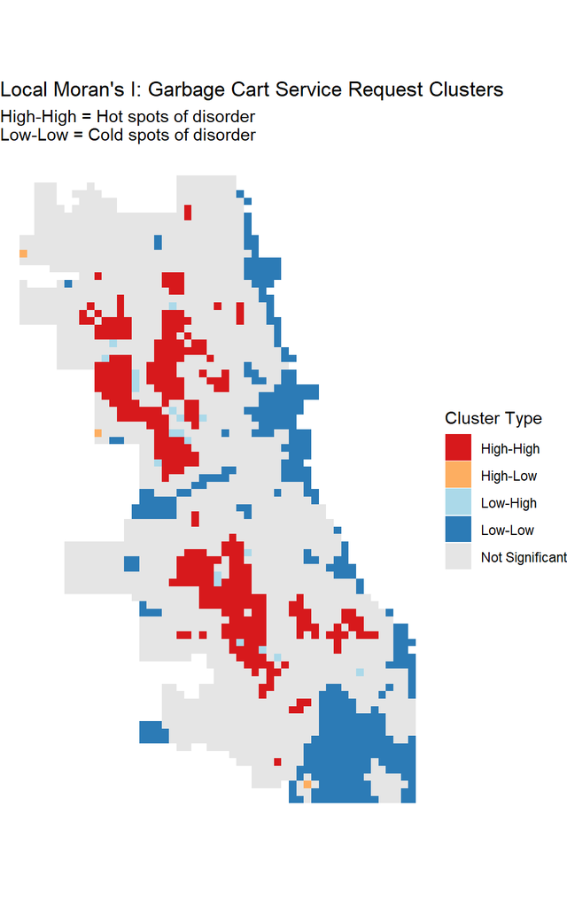

```r
# Visualize hot spots
ggplot() +
  geom_sf(
    data = fishnet,
    aes(fill = moran_class),
    color = NA
  ) +
  scale_fill_manual(
    values = c(
      "High-High" = "#d7191c",
      "High-Low" = "#fdae61",
      "Low-High" = "#abd9e9",
      "Low-Low" = "#2c7bb6",
      "Not Significant" = "gray90"
    ),
    name = "Cluster Type"
  ) +
  labs(
    title = "Local Moran's I: Garbage Cart Service Request Clusters",
    subtitle = "High-High = Hot spots of disorder\nLow-Low = Cold spots of disorder"
  ) +
  theme_void()
```

```r
# Get centroids of "High-High" cells (hot spots)
hotspots <- fishnet %>%
  filter(moran_class == "High-High") %>%
  st_centroid()

# Calculate distance from each cell to nearest hot spot
if (nrow(hotspots) > 0) {
  fishnet <- fishnet %>%
    mutate(
      dist_to_hotspot = as.numeric(
        st_distance(st_centroid(fishnet), hotspots %>% st_union())
      )
    )

  cat("✓ Calculated distance to garbage carts hot spots\n")
  cat("  - Number of hot spot cells:", nrow(hotspots), "\n")
} else {
  fishnet <- fishnet %>%
    mutate(dist_to_hotspot = 0)
  cat("⚠ No significant hot spots found\n")
}
```

```
✓ Calculated distance to garbage carts hot spots
  - Number of hot spot cells: 330
```

```r
options(tigris_use_cache = TRUE)

library(tidycensus)

# Pull median household income by tract for Cook County (Chicago)
chicago_income <- get_acs(
  geography = "tract",
  variables = "B19013_001",
  state = "IL",
  county = "Cook",
  year = 2022,
  geometry = TRUE        # pulls tract boundaries as sf object
) %>%
  st_transform('ESRI:102271') %>%   # match your project CRS
  rename(med_hh_income = estimate)

# Quick check
summary(chicago_income$med_hh_income)
```

```
   Min. 1st Qu.  Median    Mean 3rd Qu.    Max.    NA's
  13438   52756   74320   82831  104066  250001      16
```

```r
# Join HH income information to fishnet
fishnet <- st_join(fishnet, chicago_income, join = st_intersects, left = TRUE) %>%
  filter(!is.na(uniqueID)) %>%
  group_by(uniqueID) %>%
  summarize(
    across(c(countcarts, carts.nn, dist_to_hotspot, countBurglaries), first),
    med_hh_income = mean(med_hh_income, na.rm = TRUE)
  )

cat("✓ Joined Median Household Income\n")
```

```
✓ Joined Median Household Income
```

```r
cat("  - Census Tracts:", length(unique(fishnet$uniqueID)), "\n")
```

```
  - Census Tracts: 2458
```

```r
cat("  - Cells:", nrow(fishnet), "\n")
```

```
  - Cells: 2458
```

```r
# Join district information to fishnet
fishnet <- st_join(
  fishnet,
  policeDistricts,
  join = st_within,
  left = TRUE
) %>%
  filter(!is.na(District))  # Remove cells outside districts

cat("✓ Joined police districts\n")
```

```
✓ Joined police districts
```

```r
cat("  - Districts:", length(unique(fishnet$District)), "\n")
```

```
  - Districts: 22
```

```r
cat("  - Cells:", nrow(fishnet), "\n")
```

```
  - Cells: 1708
```

#### Part 4: Count Regression Models

- Fit Poisson regression
- Fit Negative Binomial regression
- Compare model fit (AIC)

```r
# Create clean modeling dataset
fishnet_model <- fishnet %>%
  st_drop_geometry() %>%
  dplyr::select(uniqueID, District, countcarts, carts.nn,
                dist_to_hotspot, med_hh_income, countBurglaries) %>%
  mutate(across(everything(), as.numeric)) %>%
  mutate(across(everything(), ~ifelse(!is.finite(.), NA, .))) %>%
  na.omit() %>%
  # ← Cap outliers at 99th percentile
  mutate(across(
    c(countcarts, carts.nn, dist_to_hotspot, med_hh_income),
    ~ pmin(., quantile(., 0.99, na.rm = TRUE))
  )) %>%
  mutate(across(
    c(countcarts, carts.nn, dist_to_hotspot, med_hh_income),
    ~ as.numeric(scale(.)),
    .names = "{.col}_z"
  )) %>%
  filter(if_all(ends_with("_z"), ~ is.finite(.)))
# Verify clean
fishnet_model %>%
  summarise(across(everything(),
                   ~sum(is.na(.) | is.nan(.) | is.infinite(.))))
```

```
# A tibble: 1 × 11
  uniqueID District countcarts carts.nn dist_to_hotspot med_hh_income
     <int>    <int>      <int>    <int>           <int>         <int>
1        0        0          0        0               0             0
# ℹ 5 more variables: countBurglaries <int>, countcarts_z <int>,
#   carts.nn_z <int>, dist_to_hotspot_z <int>, med_hh_income_z <int>
```

```r
cat("✓ Prepared modeling data\n")
```

```
✓ Prepared modeling data
```

```r
cat("  - Observations:", nrow(fishnet_model), "\n")
```

```
  - Observations: 1682
```

```r
cat("  - Variables:", ncol(fishnet_model), "\n")
```

```
  - Variables: 11
```

```r
# Fit Poisson regression
model_poisson <- glm(
  countBurglaries ~ countcarts_z + carts.nn_z + dist_to_hotspot_z + med_hh_income_z,
  data = fishnet_model,
  family = "poisson"
)

# Summary
summary(model_poisson)
```

```
Call:
glm(formula = countBurglaries ~ countcarts_z + carts.nn_z + dist_to_hotspot_z +
    med_hh_income_z, family = "poisson", data = fishnet_model)

Coefficients:
                  Estimate Std. Error z value             Pr(>|z|)
(Intercept)        0.86725    0.02453  35.354 < 0.0000000000000002 ***
countcarts_z       0.09056    0.01789   5.062      0.0000004138483 ***
carts.nn_z        -1.18180    0.06517 -18.133 < 0.0000000000000002 ***
dist_to_hotspot_z -0.29895    0.02005 -14.909 < 0.0000000000000002 ***
med_hh_income_z   -0.09676    0.01447  -6.687      0.0000000000228 ***
---
Signif. codes:  0 '***' 0.001 '**' 0.01 '*' 0.05 '.' 0.1 ' ' 1

(Dispersion parameter for poisson family taken to be 1)

    Null deviance: 6551.1  on 1681  degrees of freedom
Residual deviance: 4202.7  on 1677  degrees of freedom
AIC: 8261.3

Number of Fisher Scoring iterations: 6
```

```r
# Calculate dispersion parameter
dispersion <- sum(residuals(model_poisson, type = "pearson")^2) /
              model_poisson$df.residual

cat("Dispersion parameter:", round(dispersion, 2), "\n")
```

```
Dispersion parameter: 2.95
```

```r
cat("Rule of thumb: >1.5 suggests overdispersion\n")
```

```
Rule of thumb: >1.5 suggests overdispersion
```

```r
if (dispersion > 1.5) {
  cat("⚠ Overdispersion detected! Consider Negative Binomial model.\n")
} else {
  cat("✓ Dispersion looks okay for Poisson model.\n")
}
```

```
⚠ Overdispersion detected! Consider Negative Binomial model.
```

```r
# Fit Negative Binomial model
model_nb <- glm.nb(
  countBurglaries ~ countcarts_z + carts.nn_z + dist_to_hotspot_z + med_hh_income_z,
  data = fishnet_model,
  control = glm.control(maxit = 100)
)

# Summary
summary(model_nb)
```

```
Call:
glm.nb(formula = countBurglaries ~ countcarts_z + carts.nn_z +
    dist_to_hotspot_z + med_hh_income_z, data = fishnet_model,
    control = glm.control(maxit = 100), init.theta = 2.186494035,
    link = log)

Coefficients:
                  Estimate Std. Error z value             Pr(>|z|)
(Intercept)        0.83654    0.03306  25.305 < 0.0000000000000002 ***
countcarts_z       0.05941    0.03216   1.847              0.06473 .
carts.nn_z        -1.31481    0.09048 -14.531 < 0.0000000000000002 ***
dist_to_hotspot_z -0.30186    0.02998 -10.070 < 0.0000000000000002 ***
med_hh_income_z   -0.07663    0.02363  -3.243              0.00118 **
---
Signif. codes:  0 '***' 0.001 '**' 0.01 '*' 0.05 '.' 0.1 ' ' 1

(Dispersion parameter for Negative Binomial(2.1865) family taken to be 1)

    Null deviance: 2867.3  on 1681  degrees of freedom
Residual deviance: 1791.7  on 1677  degrees of freedom
AIC: 7222.3

Number of Fisher Scoring iterations: 1

              Theta:  2.186
          Std. Err.:  0.138

 2 x log-likelihood:  -7210.324
```

```r
# Compare AIC (lower is better)
cat("\nModel Comparison:\n")
```

```
Model Comparison:
```

```r
cat("Poisson AIC:", round(AIC(model_poisson), 1), "\n")
```

```
Poisson AIC: 8261.3
```

```r
cat("Negative Binomial AIC:", round(AIC(model_nb), 1), "\n")
```

```
Negative Binomial AIC: 7222.3
```

#### Part 5: Spatial Cross-Validation (2017)

- Implement Leave-One-Group-Out cross-validation on 2017 data
- Calculate and report error metrics (MAE, RMSE)

```r
# Get unique districts
districts <- unique(fishnet_model$District)
cv_results <- tibble()

cat("Running LOGO Cross-Validation...\n")
```

```
Running LOGO Cross-Validation...
```

```r
for (i in seq_along(districts)) {

  test_district <- districts[i]

  # Split data
  train_data <- fishnet_model %>% filter(District != test_district)
  test_data <- fishnet_model %>% filter(District == test_district)

  # Fit model on training data
  model_cv <- glm.nb(
    countBurglaries ~ countcarts_z + carts.nn_z + dist_to_hotspot_z + med_hh_income_z,
    data = train_data
  )

  # Predict on test data
  test_data <- test_data %>%
    mutate(
      prediction = predict(model_cv, test_data, type = "response")
    )

  # Calculate metrics
  mae <- mean(abs(test_data$countBurglaries - test_data$prediction))
  rmse <- sqrt(mean((test_data$countBurglaries - test_data$prediction)^2))

  # Store results
  cv_results <- bind_rows(
    cv_results,
    tibble(
      fold = i,
      test_district = test_district,
      n_test = nrow(test_data),
      mae = mae,
      rmse = rmse
    )
  )

  cat("  Fold", i, "/", length(districts), "- District", test_district,
      "- MAE:", round(mae, 2), "\n")
}
```

```
  Fold 1 / 22 - District 5 - MAE: 1.75
  Fold 2 / 22 - District 4 - MAE: 1.45
  Fold 3 / 22 - District 22 - MAE: 2.28
  Fold 4 / 22 - District 6 - MAE: 2.87
  Fold 5 / 22 - District 8 - MAE: 2.19
  Fold 6 / 22 - District 7 - MAE: 2.35
  Fold 7 / 22 - District 3 - MAE: 5.84
  Fold 8 / 22 - District 2 - MAE: 2.83
  Fold 9 / 22 - District 9 - MAE: 1.79
  Fold 10 / 22 - District 10 - MAE: 2.15
  Fold 11 / 22 - District 1 - MAE: 2.43
  Fold 12 / 22 - District 12 - MAE: 3.3
  Fold 13 / 22 - District 15 - MAE: 2.04
  Fold 14 / 22 - District 11 - MAE: 2.98
  Fold 15 / 22 - District 18 - MAE: 2.53
  Fold 16 / 22 - District 25 - MAE: 2.53
  Fold 17 / 22 - District 14 - MAE: 2.86
  Fold 18 / 22 - District 19 - MAE: 2.03
  Fold 19 / 22 - District 16 - MAE: 2.34
  Fold 20 / 22 - District 17 - MAE: 2.03
  Fold 21 / 22 - District 20 - MAE: 1.79
  Fold 22 / 22 - District 24 - MAE: 2.35
```

```r
# Overall results
cat("\n✓ Cross-Validation Complete\n")
```

```
✓ Cross-Validation Complete
```

```r
cat("Mean MAE:", round(mean(cv_results$mae), 2), "\n")
```

```
Mean MAE: 2.49
```

```r
cat("Mean RMSE:", round(mean(cv_results$rmse), 2), "\n")
```

```
Mean RMSE: 3.38
```

```r
# Show results
cv_results %>%
  arrange(desc(mae)) %>%
  kable(
    digits = 2,
    caption = "LOGO CV Results by District"
  ) %>%
  kable_styling(bootstrap_options = c("striped", "hover"))
```

LOGO CV Results by District

| fold | test_district | n_test | mae | rmse |
| --- | --- | --- | --- | --- |
| 7 | 3 | 43 | 5.84 | 7.97 |
| 12 | 12 | 73 | 3.30 | 4.84 |
| 14 | 11 | 43 | 2.98 | 3.51 |
| 4 | 6 | 63 | 2.87 | 4.14 |
| 17 | 14 | 46 | 2.86 | 4.20 |
| 8 | 2 | 56 | 2.83 | 3.91 |
| 16 | 25 | 85 | 2.53 | 3.25 |
| 15 | 18 | 30 | 2.53 | 4.48 |
| 11 | 1 | 28 | 2.43 | 3.38 |
| 6 | 7 | 52 | 2.35 | 3.02 |
| 22 | 24 | 41 | 2.35 | 2.84 |
| 19 | 16 | 129 | 2.34 | 2.70 |
| 3 | 22 | 112 | 2.28 | 2.67 |
| 5 | 8 | 191 | 2.19 | 3.12 |
| 10 | 10 | 63 | 2.15 | 2.87 |
| 13 | 15 | 32 | 2.04 | 2.35 |
| 20 | 17 | 82 | 2.03 | 2.39 |
| 18 | 19 | 63 | 2.03 | 2.47 |
| 21 | 20 | 30 | 1.79 | 2.15 |
| 9 | 9 | 107 | 1.79 | 2.34 |
| 1 | 5 | 98 | 1.75 | 2.42 |
| 2 | 4 | 215 | 1.45 | 3.30 |

#### Part 6: Model Evaluation

- Compare to KDE baseline

```r
# Convert burglaries to ppp (point pattern) format for spatstat
burglaries_ppp <- as.ppp(
  st_coordinates(burglaries),
  W = as.owin(st_bbox(chicagoBoundary))
)

# Calculate KDE with 1k ft bandwidth
kde_burglaries <- density.ppp(
  burglaries_ppp,
  sigma = 1000,  # 1k ft bandwidth
  edge = TRUE    # Edge correction
)

# Convert to terra raster (modern approach, not raster::raster)
kde_raster <- rast(kde_burglaries)

# Extract KDE values to fishnet cells
fishnet <- fishnet %>%
  mutate(
    kde_value = terra::extract(
      kde_raster,
      vect(fishnet),
      fun = mean,
      na.rm = TRUE
    )[, 2]  # Extract just the values column
  )

cat("✓ Calculated KDE baseline\n")
```

```
✓ Calculated KDE baseline
```

```r
# Fit final model on all data
final_model <- glm.nb(
  countBurglaries ~ countcarts_z + carts.nn_z + dist_to_hotspot_z + med_hh_income_z,
  data = fishnet_model
)

# Add predictions back to fishnet
fishnet <- fishnet %>%
  mutate(
    prediction_nb = predict(final_model, fishnet_model, type = "response")[match(uniqueID, fishnet_model$uniqueID)]
  )

# Also add KDE predictions (normalize to same scale as counts)
kde_sum <- sum(fishnet$kde_value, na.rm = TRUE)
count_sum <- sum(fishnet$countBurglaries, na.rm = TRUE)
fishnet <- fishnet %>%
  mutate(
    prediction_kde = (kde_value / kde_sum) * count_sum
  )
```

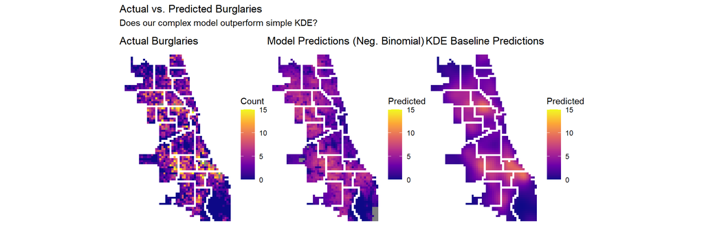

```r
# Create three maps
p1 <- ggplot() +
  geom_sf(data = fishnet, aes(fill = countBurglaries), color = NA) +
  scale_fill_viridis_c(name = "Count", option = "plasma", limits = c(0, 15)) +
  labs(title = "Actual Burglaries") +
  theme_void()

p2 <- ggplot() +
  geom_sf(data = fishnet, aes(fill = prediction_nb), color = NA) +
  scale_fill_viridis_c(name = "Predicted", option = "plasma", limits = c(0, 15)) +
  labs(title = "Model Predictions (Neg. Binomial)") +
  theme_void()

p3 <- ggplot() +
  geom_sf(data = fishnet, aes(fill = prediction_kde), color = NA) +
  scale_fill_viridis_c(name = "Predicted", option = "plasma", limits = c(0, 15)) +
  labs(title = "KDE Baseline Predictions") +
  theme_void()

p1 + p2 + p3 +
  plot_annotation(
    title = "Actual vs. Predicted Burglaries",
    subtitle = "Does our complex model outperform simple KDE?"
  )
```

```r
# Calculate performance metrics
comparison <- fishnet %>%
  st_drop_geometry() %>%
  filter(!is.na(prediction_nb), !is.na(prediction_kde)) %>%
  summarize(
    model_mae = mean(abs(countBurglaries - prediction_nb)),
    model_rmse = sqrt(mean((countBurglaries - prediction_nb)^2)),
    kde_mae = mean(abs(countBurglaries - prediction_kde)),
    kde_rmse = sqrt(mean((countBurglaries - prediction_kde)^2))
  )

comparison %>%
  pivot_longer(everything(), names_to = "metric", values_to = "value") %>%
  separate(metric, into = c("approach", "metric"), sep = "_") %>%
  pivot_wider(names_from = metric, values_from = value) %>%
  kable(
    digits = 2,
    caption = "Model Performance Comparison"
  ) %>%
  kable_styling(bootstrap_options = c("striped", "hover"))
```

Model Performance Comparison

| approach | mae | rmse |
| --- | --- | --- |
| model | 2.24 | 3.29 |
| kde | 2.07 | 2.97 |

#### CHALLENGE TASK: Temporal Validation (2018) *not mandatory, only if you want very strong spatial analytics muscles*

- Download 2018 crimes https://data.cityofchicago.org/Public-Safety/Crimes-2018/3i3m-jwuy/about_data
- Be sure to filter for BURGLARIES (FORCED ENTRY only to match the 2017 data)
- Aggregate 2018 violations to the same fishnet grid
- Use your 2017 model to predict 2018 counts
- Calculate temporal validation metrics
- Compare spatial vs. temporal validation performance

## Step 3: Write Your Analysis

### Critical Requirement: Explain Each Step

**For each major section, you must explain in your own words:**

- **What** you are doing in that step
- **Why** this step is important for the analysis
- **What** you found or learned from the results

In this project, I chose the 311 garbage carts service requests as my predictor variable to build a spatial predictive model for burglaries in Chicago.

#### **Part 1: Data Loading & Exploration**

- **Environmental Setup**
  - In environmental setup, I loaded the necessary packages for data manipulation and spatial analysis. I also configured options to disable scientific notation and ensure reproducibility for the subsequent analysis.
- **Data Loading**
  - In data loading, four datasets including 311 garbage cart service requests (2026), Burglaries (2017), Chicago boundary, and police districts were loaded as sf objects and projected onto Illinois State Plane East, NAD83, US Feet (ESRI: 102271).
- **Visualization: Garbage Cart Service Requests in Chicago**
  - By plotting 311 garbage cart service requests as point features across Chicago, we gained an initial understanding of their spatial distribution and established a basis for comparison using either kernel density estimation or aggregation by fishnet grids across Chicago.

#### **Part 2: Fishnet Grid Creation**

- **Create Fishnet**
  - To create a fishnet for data aggregation, we used the st_make_grid function to generate 500 × 500 ft cells across the Chicago boundary and projected them into ESRI:102271. Only cells that intersect the city boundary were retained for analysis, and each cell were assigned a unique ID based on its row number.
- **Data Aggregation**
  - Once the fishnet cells were created, we used the st_join function to attach 311 cart service requests and burglary data within the Chicago boundary to the grid. Each cell was then assigned two new variables representing the counts of service requests and burglaries occurring within it. These aggregated values were subsequently joined back to the fishnet. All the NAs were replaced by 0 to avoid data manipulation error.
- **Visualization: Garbage Cart Service Request Counts by Grid Cell**
  - By mapping 311 garbage cart service requests aggregated at the grid-cell level across Chicago, we gained a clearer understanding of their spatial disparities by analyzing count data within a standardized spatial unit.

#### **Part 3: Spatial Features**

- **NN-Feature**
  - To use distance to garbage cart service requests as a predictive variable, the mean distance to multiple requests is more informative than the distance to a single request. We therefore extracted the centroid coordinates of the fishnet grid cells and the locations of all service requests across Chicago and used the get.knn function to calculate the mean distance from each grid cell to its three nearest service requests. This value was then added to the fishnet dataset as a new variable, carts.nn.
- **Local Moran’s I**
  - To examine clustering patterns of garbage cart service requests in Chicago, we calculated Local Moran’s I for each fishnet grid cell based on its five nearest neighbors. Each cell was then classified into a Moran’s I class according to its Local Moran’s I value and corresponding p-value. Both the Local Moran’s I statistics and its cluster classification were subsequently appended to the fishnet dataset.
- **Visualization: Garbage Cart Service Request Clusters**
  - By plotting the garbage cart service request clusters across Chicago by Moran’s I class, we identified spatial patterns of clustering, including areas of high-high and low-low concentrations, as well as potential spatial outliers.
- **Distance to Hotspots**
  - To incorporate distance to hotspots as a predictive variable, we extracted the centroid coordinates of grid cells classified as “high–high” and calculated the distance from each cell to its nearest hotspot. This value was then added to the fishnet dataset as a new variable, dist_to_hotspot.
- **Add Additional Variable: Median Household Income**
  - To add an additional contextual predictive variable to the model, we obtained median household income by census tract in Chicago and projected the data into ESRI:102271. The dataset was then joined to the fishnet grid. To prevent duplication during the join, we collapsed repeated entries using group_by(). For grid cells intersecting multiple tracts, the median household income was averaged across the overlapping tracts.
- **Join Police Districts**
  - To prepare the fishnet dataset for cross-validation, police districts were spatially joined to the grid. Cells that did not fall within any police district were removed to ensure consistency throughout the analysis.

#### **Part 5: Spatial Cross-Validation**

- **Leave-One-Group-Out Cross-Validation**
  - Standard k-fold cross-validation randomly splits observations into training and test sets, whereas leave-one-group-out cross-validation accounts for spatial structure by grouping data based on geographic units. To better evaluate model performance on unseen data, we partitioned the dataset by police districts, using each district as a holdout set in turn. A model (model_cv) was trained on the remaining districts and then evaluated on the held-out district. The results showed a mean MAE of 2.49 and a mean RMSE of 3.38 across all folds.
- **Visualization: CV-Results Table**
  - The LOGO cross-validation results by police districts were visualized in a table showing the number of folds, the test district, the number of fishnet cells, MAE, and RMSE.